# Chapter 6

Guangjin Zhou

February 25, 2019

## R libraries

```r
library(ISLR);library(MASS); library(leaps);library(glmnet);library(pls)
ls("package:ISLR"); names(College); dim(College)
```

```
##  [1] "Auto"      "Caravan"   "Carseats"  "College"   "Credit"
##  [6] "Default"   "Hitters"   "Khan"      "NCI60"     "OJ"
## [11] "Portfolio" "Smarket"   "Wage"      "Weekly"
```

```
##  [1] "Private"     "Apps"        "Accept"      "Enroll"      "Top10perc"
##  [6] "Top25perc"   "F.Undergrad" "P.Undergrad" "Outstate"    "Room.Board"
## [11] "Books"       "Personal"    "PhD"         "Terminal"    "S.F.Ratio"
## [16] "perc.alumni" "Expend"      "Grad.Rate"
```

```
## [1] 777  18
```

# 9. Predict the number of applications received using the other variables in the College data set.

## (a) Split the data set into a training set and a test set.

```r
set.seed(471)
n<-nrow(College)
x<-c()

set.seed(100)
train<-sample(1:n,n/2)
test<--train
```

## (b) Fit a linear model using least squares on the training set and report the test error obtained.

```r
lm.fit<-lm(Apps~.,data=College[train,])
lm.pred<-predict(lm.fit,newdata = College[test,])
x<-c(x,lm=mean((lm.pred-College[test,"Apps"])^2 ))
x
```

```
##      lm
## 1355557
```

The mean square of linear model by least square model is 1355557.

### Rige matrix

```r
ggrid <-10 ^ seq(4, -2, length=100)
train.mat <- model.matrix(Apps~., data=College[train,])
test.mat <- model.matrix(Apps~., data=College[test,])
```

### Cross model

ridge.cv$lambda.min

### test error

Report the test error obtained, along with the number of non-zero coefficient estimates.

17 x 1 sparse Matrix of class “dgCMatrix”

*(Intercept) -1.364330e+03

*Accept 1.264287e+00

*Enroll .

*Top10perc 3.850869e+01

*Top25perc -4.595076e+00

*F.Undergrad 3.380132e-02

*P.Undergrad 7.214142e-02

*Outstate -8.197778e-02

*Room.Board 2.618713e-01

*Personal .

*PhD -2.243368e+00

*Terminal .

*S.F.Ratio .

*perc.alumni -1.614927e+01

*Expend 6.392972e-02

*Grad.Rate 6.941991e+00

lasso.cv$lambda.min; lasso.cv$coef

[1] 16.29751

## (e) Fit a PCR model on the training set, with M chosen by crossvalidation.

Report the test error obtained, along with the value of M selected by cross-validation.

```r
set.seed(471)

pcr.fit<-pcr(Apps~.,data=College,scale=TRUE,validation='CV',subset=train)
pcr.fit$ncomp
```

```
## [1] 17
```

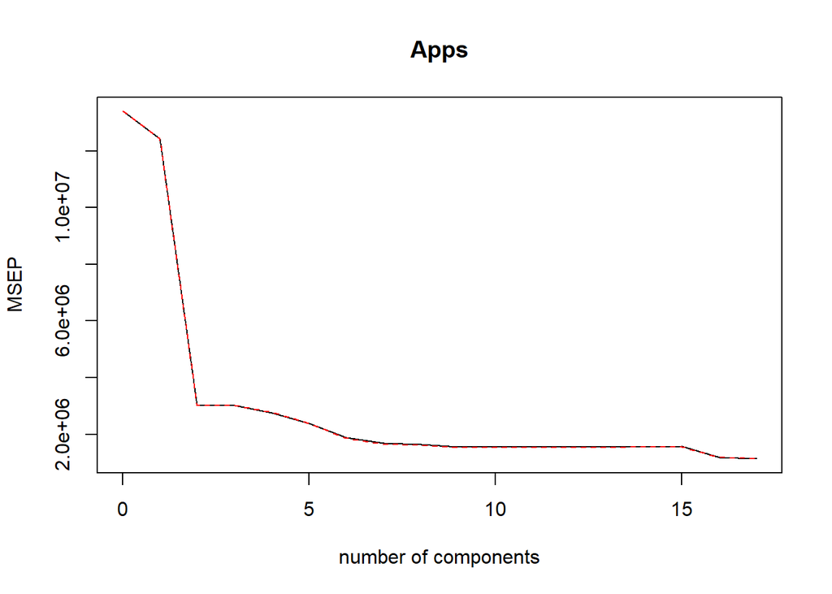

```r
validationplot(pcr.fit,val.type="MSEP");
```

```r
pcr.pred<-predict(pcr.fit,newdata = College[test,-c(2)],ncomp = 16)
x3=c(x,pcr=mean( (pcr.pred-College[test,2])^2));x3
```

```
##      lm     pcr
## 1355557 1531268
```

## (f) Fit a PLS model on the training set, with M chosen by crossvalidation.

Report the test error obtained, along with the value of M selected by cross-validation.

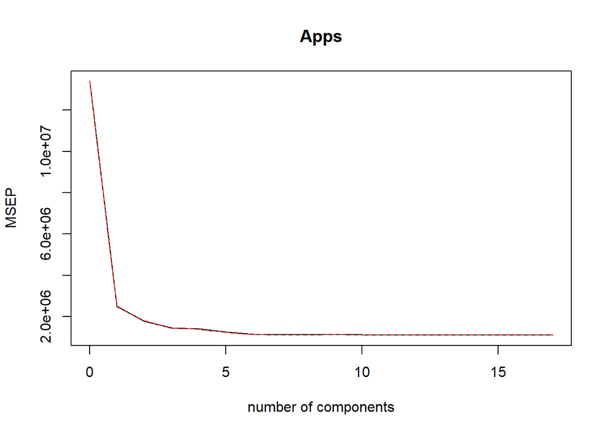

```r
pls.fit<-plsr(Apps~.,data=College,scale=TRUE,validation='CV',subset=train)
validationplot(pls.fit,val.type="MSEP")
```

```r
pls.fit$ncomp
```

```
## [1] 17
```

```r
pls.pred=predict(pls.fit,newdata = College[test,-c(2)],ncomp = 10)
x4=c(x,pls=mean( (pls.pred-College[test,2])^2));x4
```

```
##      lm     pls
## 1355557 1365337
```

## (g) Comment on the results obtained.

How accurately can we predict the number of college applications received? Is there much difference among the test errors resulting from these five approaches?

```r
sort(x)
```

```
##      lm
## 1355557
```

```r
summary(lm.fit)
```

```
##
## Call:
## lm(formula = Apps ~ ., data = College[train, ])
##
## Residuals:
##     Min      1Q  Median      3Q     Max
## -2842.8  -487.6   -90.9   347.3  5224.9
##
## Coefficients:
##               Estimate Std. Error t value Pr(>|t|)
## (Intercept) -4.967e+02  5.513e+02  -0.901 0.368171
## PrivateYes  -5.574e+02  1.896e+02  -2.941 0.003482 **
## Accept       1.342e+00  6.902e-02  19.451  < 2e-16 ***
## Enroll      -6.678e-01  2.465e-01  -2.709 0.007070 **
## Top10perc    5.059e+01  7.358e+00   6.876 2.64e-11 ***
## Top25perc   -1.422e+01  6.140e+00  -2.316 0.021121 *
## F.Undergrad  1.097e-01  3.888e-02   2.821 0.005039 **
## P.Undergrad  7.432e-02  3.893e-02   1.909 0.057031 .
## Outstate    -7.834e-02  2.741e-02  -2.858 0.004501 **
## Room.Board   3.032e-01  6.717e-02   4.514 8.56e-06 ***
## Books        2.648e-02  3.577e-01   0.074 0.941029
## Personal     8.379e-03  9.253e-02   0.091 0.927894
## PhD         -7.400e+00  6.474e+00  -1.143 0.253776
## Terminal    -2.347e+00  7.030e+00  -0.334 0.738667
## S.F.Ratio   -1.447e+01  1.823e+01  -0.794 0.427878
## perc.alumni -1.319e+01  5.674e+00  -2.325 0.020606 *
## Expend       6.334e-02  1.725e-02   3.671 0.000277 ***
## Grad.Rate    1.124e+01  4.067e+00   2.764 0.005989 **
## ---
## Signif. codes:  0 '***' 0.001 '**' 0.01 '*' 0.05 '.' 0.1 ' ' 1
##
## Residual standard error: 997.5 on 370 degrees of freedom
## Multiple R-squared:  0.9288, Adjusted R-squared:  0.9256
## F-statistic: 284.1 on 17 and 370 DF,  p-value: < 2.2e-16
```

```r
avg_apps<-mean(College[,"Apps"]); avg_apps
```

```
## [1] 3001.638
```

```r
1 - mean((College[test, "Apps"] - lm.pred)^2)
```

```
## [1] -1355556
```

```r
1 - mean((College[test, "Apps"] - lm.pred)^2) /mean((College[test, "Apps"] - avg_apps)^2)
```

```
## [1] 0.9180139
```

Conclusion:The average application unit is 3002, the best performing model with MSE 1,355,557 and 91% of variance is explained by the model.

# 11. Predict per capita crime rate in the Boston data set.

```r
names(Boston);
```

```
##  [1] "crim"    "zn"      "indus"   "chas"    "nox"     "rm"      "age"
##  [8] "dis"     "rad"     "tax"     "ptratio" "black"   "lstat"   "medv"
```

```r
apply(is.na(Boston),2,sum)
```

```
##    crim      zn   indus    chas     nox      rm     age     dis     rad
##       0       0       0       0       0       0       0       0       0
##     tax ptratio   black   lstat    medv
##       0       0       0       0       0
```

```r
# split data into training and test sets
set.seed(1)
trainid <- sample(1:nrow(Boston), nrow(Boston)/2)
train <- Boston[trainid,]
test <- Boston[-trainid,]
xmat.train <- model.matrix(crim~., data=train)[,-1]
xmat.test <- model.matrix(crim~., data=test)[,-1]
```

## (a) Try out some of the regression methods explored in this chapter,

such as best subset selection, the lasso, ridge regression, and PCR. Present and discuss results for the approaches that you consider.

### Best subset

```r
set.seed(471)


predict.regsubsets <- function(object, newdata, id, ...){
  form <- as.formula(object$call[[2]])
  mat <- model.matrix(form, newdata)
  coefi <- coef(object, id=id)
  xvars <- names(coefi)
  mat[,xvars]%*%coefi
}

# forward selection
fit.fwd <- regsubsets(crim~., data=train, nvmax=ncol(Boston)-1)
(fwd.summary <- summary(fit.fwd))
```

```
## Subset selection object
## Call: regsubsets.formula(crim ~ ., data = train, nvmax = ncol(Boston) -
##     1)
## 13 Variables  (and intercept)
##         Forced in Forced out
## zn          FALSE      FALSE
## indus       FALSE      FALSE
## chas        FALSE      FALSE
## nox         FALSE      FALSE
## rm          FALSE      FALSE
## age         FALSE      FALSE
## dis         FALSE      FALSE
## rad         FALSE      FALSE
## tax         FALSE      FALSE
## ptratio     FALSE      FALSE
## black       FALSE      FALSE
## lstat       FALSE      FALSE
## medv        FALSE      FALSE
## 1 subsets of each size up to 13
## Selection Algorithm: exhaustive
##           zn  indus chas nox rm  age dis rad tax ptratio black lstat medv
## 1  ( 1 )  " " " "   " "  " " " " " " " " "*" " " " "     " "   " "   " "
## 2  ( 1 )  " " " "   " "  " " " " " " " " "*" " " " "     " "   "*"   " "
## 3  ( 1 )  " " " "   " "  " " "*" " " " " "*" " " " "     " "   "*"   " "
## 4  ( 1 )  "*" " "   " "  " " " " " " "*" "*" " " " "     " "   " "   "*"
## 5  ( 1 )  "*" " "   " "  "*" " " " " "*" "*" " " " "     " "   " "   "*"
## 6  ( 1 )  "*" " "   " "  "*" "*" " " "*" "*" " " " "     " "   " "   "*"
## 7  ( 1 )  "*" " "   " "  "*" "*" " " "*" "*" " " " "     " "   "*"   "*"
## 8  ( 1 )  "*" " "   " "  "*" "*" " " "*" "*" " " "*"     " "   "*"   "*"
## 9  ( 1 )  "*" " "   " "  "*" "*" " " "*" "*" "*" "*"     " "   "*"   "*"
## 10  ( 1 ) "*" " "   "*"  "*" "*" " " "*" "*" "*" "*"     " "   "*"   "*"
## 11  ( 1 ) "*" " "   "*"  "*" "*" " " "*" "*" "*" "*"     "*"   "*"   "*"
## 12  ( 1 ) "*" " "   "*"  "*" "*" "*" "*" "*" "*" "*"     "*"   "*"   "*"
## 13  ( 1 ) "*" "*"   "*"  "*" "*" "*" "*" "*" "*" "*"     "*"   "*"   "*"
```

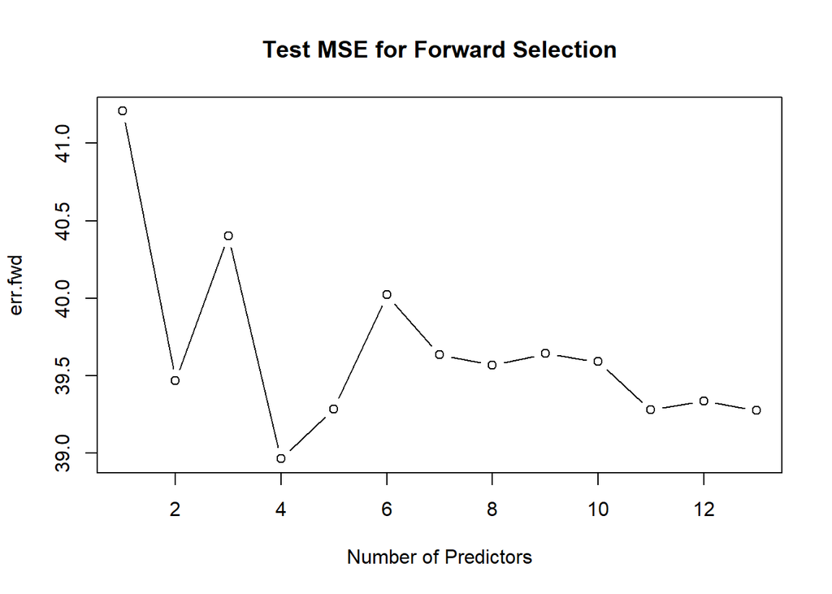

```r
err.fwd <- rep(NA, ncol(Boston)-1)
for(i in 1:(ncol(Boston)-1)) {
  pred.fwd <- predict(fit.fwd, test, id=i)
  err.fwd[i] <- mean((test$crim - pred.fwd)^2)
}
plot(err.fwd, type="b", main="Test MSE for Forward Selection", xlab="Number of Predictors")
```

## (b) Propose a model (or set of models)

that seem to perform well on this data set, and justify your answer. Make sure that you are evaluating model performance using validation set error, crossvalidation, or some other reasonable alternative, as opposed to using training error.

### 4 predictors model based best subsets approach

I chose zn, dis, rad and medv to predict crim based on lowest MSE from best subset approach.

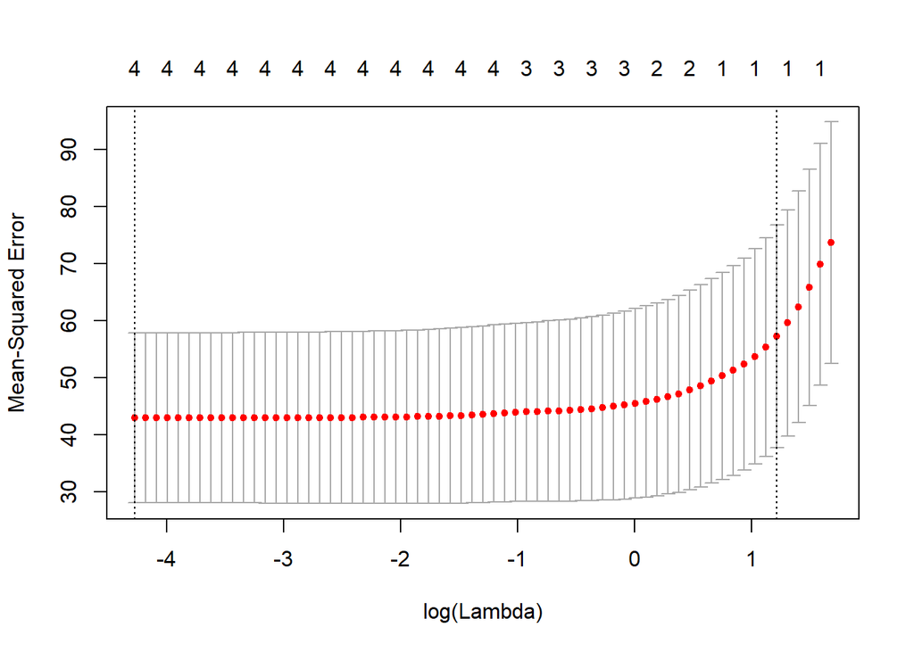

```r
x <- model.matrix(crim ~ zn+dis+rad+medv, data=Boston)
y <- Boston$crim
cv.out <- cv.glmnet(x, y, alpha = 1, type.measure = "mse")
plot(cv.out)
```

### Ridge regression

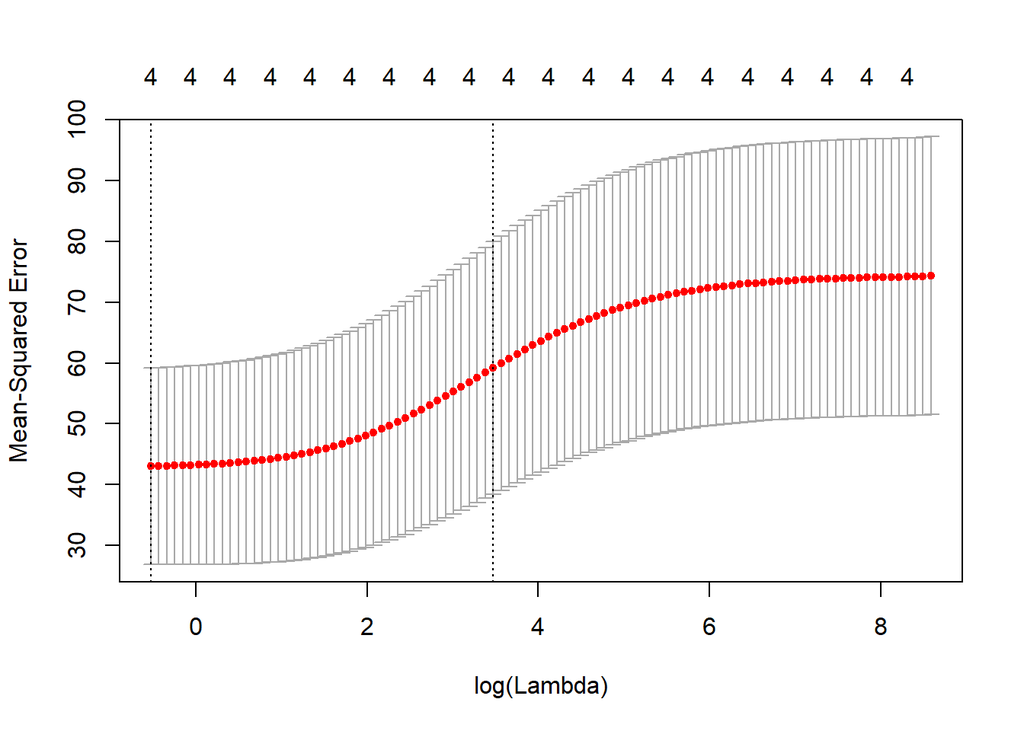

```r
cv.out.ridge <- cv.glmnet(x, y, alpha = 0, type.measure = "mse")
plot(cv.out.ridge)
```

### PCR fit

```r
pcr.fit <- pcr(crim ~zn+dis+rad+medv, data = Boston, scale = TRUE, validation = "CV")
summary(pcr.fit)
```

```
## Data:    X dimension: 506 4
##  Y dimension: 506 1
## Fit method: svdpc
## Number of components considered: 4
##
## VALIDATION: RMSEP
## Cross-validated using 10 random segments.
##        (Intercept)  1 comps  2 comps  3 comps  4 comps
## CV            8.61    7.394    7.045    6.555    6.551
## adjCV         8.61    7.390    7.041    6.551    6.546
##
## TRAINING: % variance explained
##       1 comps  2 comps  3 comps  4 comps
## X       56.24    76.74    93.29   100.00
## crim    27.07    33.77    43.13    43.35
```

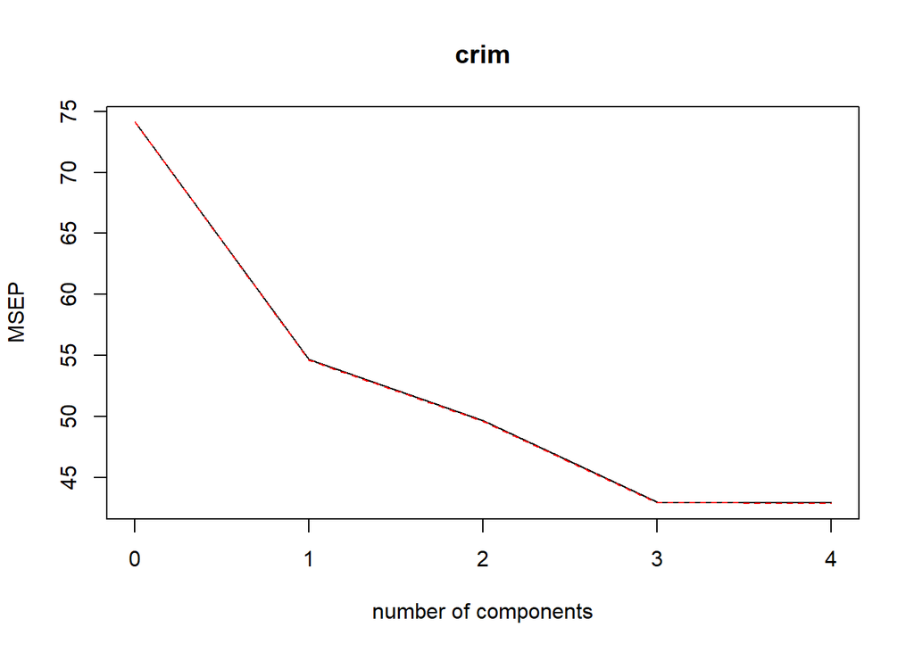

```r
validationplot(pcr.fit, val.type = "MSEP")
```

## (c) Does your chosen model involve all of the features in the dataset? Why or why not?

As shown above, the model with the 4 predictors looks have very low cross-validation error based on different model approches.